# Assessment-Urban Analytics and City Science

2521574

2024-12-3

Word count: 3,182

1. Abstract

Background: In the past 20 years, there has been a lot of internal migration in Africa, and malaria infection is a constant threat to the health of African citizens. The research project aims to determine whether specific socioeconomic factors and specific disease infections have an impact on intra-African migration flows.

Objective: This report analyzes the spatial network of internal migration flows in African countries from 2005 to 2010, discusses the importance of migration network and its relationship with socio-economic factors and disease transmission, and provides a basis for policy recommendations

2. Introduction

2.1 Background

In the process of human development, migration is an important issue for the vigorous development of mankind. Migration is caused by a variety of factors. Since ancient times, human beings have had to migrate, which is due to various natural and objective factors such as the threat of predators and the impact of harsh climate, to today, with the acceleration of urbanization around the world, human migration has begun based on various subjective or objective reasons, and is no longer limited to nature. The rapid and complex interweaving of human interactions, human interactions with cities, and human interactions with nations are driving the next era of humanity around the world, and by understanding the core drivers of migration and mobility, we can better answer a key question: What shapes human mobility and convergence?

Africa is considered to be one of the origins of the human race, from which the human race moved to the world, so a typical example of African migration provides a valuable perspective on this phenomenon. Focusing on South Africa and Zambia, the study analysed internal migration flows from 2005 to 2010, using South Africa and Zambia as control groups to uncover core patterns of migration flows, drivers and their relationship to population, health and social development. This not only helps us to understand the migration law, but also provides positive suggestions for optimizing policies and improving the efficiency of resource allocation in the future.

3. Specific Problems

Space networks are critical to understanding human movement and its effects. This report focuses on migration networks in South Africa and Zambia, using spatial network analysis to explore migration flow centers in South Africa and Zambia, as well as changes in the number of malaria cases and population changes that may have an impact on migration patterns. The role of HDI changes in the network.

1. How did the provincial migration flow flow in South Africa and Zambia in 2005-10?
2. Where is the provincial center of migration flow in South Africa and Zambia in 2005-10?
3. What is the correlation between migration flows and changes in malaria incidence? population and HDI in South Africa and Zambia from 2005-10?
4. How do changes in malaria incidence, population, HDI and other variables affect migration trends in South Africa and Zambia from 2005-10?
5. Comparative analysis of data between the two countries to provide basis for policy development recommendations?

```r
#0.0 Load the relevant packages
options(warn = -1)
# Eliminates installation package warnings
library(readr)
library(tidyverse)
library(sf)
library(rprojroot)
library(dplyr)
library(ggplot2)
library(gridExtra)
library(igraph)
library(tibble)
library(kableExtra)
library(corrplot)
library(broom)
options(warn = 0)
```

4. Data Source

4.1 Migration Data: Source: Five-year internal migration flows (2005–2010) from WorldPop datasets (http://www.worldpop.org.uk/). Content: Migration flow data for South Africa and Zambia.

4.2 Basic Map Data: Source: geoBoundaries dataset (http://www.geoboundaries.org/). Content: Provincial administrative boundary maps for South Africa and Zambia.

4.3 Socio-economic Data: Population Data: Zambia: Census data from 2005–2010 (https://zambia.opendataforafrica.org/). South Africa: Census data from 2001–2010 (https://www.statssa.gov.za/). Human Development Index (HDI): Source: Provincial-level HDI data from Global Data Lab (https://globaldatalab.org/).

4.4 Health Data: Malaria Cases: Zambia: Health reports and malaria incidence data from 2005–2010 (https://zambia.opendataforafrica.org/). South Africa: Published data on malaria cases at the provincial level (Maharaj et al. 2013).

4.5 Preprocessing Steps: Field Selection: Extract relevant fields (migration flows, population changes, HDI values, malaria cases). Boundary Matching: Use shapefiles from geoBoundaries to align migration nodes with administrative boundaries. Data Cleaning: Remove intra-provincial migration flows to focus on inter-provincial dynamics. Consistency Checks: Ensure that all datasets are aligned spatially and temporally for analysis consistency.

The below code loads the data.

```r
#0.Import Migration Flow (Basic) Files
  ## Set the path
path <- find_rstudio_root_file()
  ## Read the files
file_paths <- c(
  file.path(path, "data/ZAF_5yrs_InternalMigFlows_2010.csv"),
  file.path(path, "data/ZMB_5yrs_InternalMigFlows_2010.csv")
)
data_list <- lapply(file_paths, read_csv)
names(data_list) <- c("ZAF", "ZMB")
ZAF <- data_list[["ZAF"]]
ZMB <- data_list[["ZMB"]]
  ## Preview
glimpse(ZAF)
```

```
## Rows: 72
## Columns: 8
## $ ISO    <chr> "ZAF", "ZAF", "ZAF", "ZAF", "ZAF", "ZAF", "ZAF", "ZAF", "ZAF", …
## $ NODEI  <dbl> 2, 3, 4, 5, 6, 7, 8, 9, 1, 3, 4, 5, 6, 7, 8, 9, 1, 2, 4, 5, 6, …
## $ NODEJ  <dbl> 1, 1, 1, 1, 1, 1, 1, 1, 2, 2, 2, 2, 2, 2, 2, 2, 3, 3, 3, 3, 3, …
## $ LONFR  <dbl> 26.46742, 21.34706, 26.86447, 30.72498, 25.33597, 28.20923, 30.…
## $ LATFR  <dbl> -32.14189, -29.52580, -28.61012, -28.70839, -26.31898, -26.0453…
## $ LONTO  <dbl> 20.61418, 20.61418, 20.61418, 20.61418, 20.61418, 20.61418, 20.…
## $ LATTO  <dbl> -33.01144, -33.01144, -33.01144, -33.01144, -33.01144, -33.0114…
## $ PrdMIG <dbl> 2242.5781, 1715.8714, 960.1820, 1524.7384, 1068.5179, 2145.8594…
```

```r
glimpse(ZMB)
```

```
## Rows: 5,112
## Columns: 8
## $ ISO    <chr> "ZMB", "ZMB", "ZMB", "ZMB", "ZMB", "ZMB", "ZMB", "ZMB", "ZMB", …
## $ NODEI  <dbl> 102, 103, 104, 105, 106, 201, 202, 203, 204, 205, 206, 207, 208…
## $ NODEJ  <dbl> 101, 101, 101, 101, 101, 101, 101, 101, 101, 101, 101, 101, 101…
## $ LONFR  <dbl> 28.35282, 28.09541, 29.52592, 26.60274, 30.44721, 27.78018, 27.…
## $ LATFR  <dbl> -14.470355, -14.135091, -14.102897, -14.995398, -13.130656, -12…
## $ LONTO  <dbl> 28.03562, 28.03562, 28.03562, 28.03562, 28.03562, 28.03562, 28.…
## $ LATTO  <dbl> -14.83439, -14.83439, -14.83439, -14.83439, -14.83439, -14.8343…
## $ PrdMIG <dbl> 3049.8176, 2511.5384, 1082.7501, 1275.5217, 317.4419, 457.8132,…
```

```r
colSums(is.na(ZAF))
```

```
##    ISO  NODEI  NODEJ  LONFR  LATFR  LONTO  LATTO PrdMIG
##      0      0      0      0      0      0      0      0
```

```r
colSums(is.na(ZMB))
```

```
##    ISO  NODEI  NODEJ  LONFR  LATFR  LONTO  LATTO PrdMIG
##      0      0      0      0      0      0      0      0
```

```r
# The data frame has no missing values, and the dataframe content is complete.
```

```r
#1. Check
typeof(ZAF)
```

```
## [1] "list"
```

```r
typeof(ZMB)
```

```
## [1] "list"
```

```r
str(ZAF)
```

```
## spc_tbl_ [72 × 8] (S3: spec_tbl_df/tbl_df/tbl/data.frame)
##  $ ISO   : chr [1:72] "ZAF" "ZAF" "ZAF" "ZAF" ...
##  $ NODEI : num [1:72] 2 3 4 5 6 7 8 9 1 3 ...
##  $ NODEJ : num [1:72] 1 1 1 1 1 1 1 1 2 2 ...
##  $ LONFR : num [1:72] 26.5 21.3 26.9 30.7 25.3 ...
##  $ LATFR : num [1:72] -32.1 -29.5 -28.6 -28.7 -26.3 ...
##  $ LONTO : num [1:72] 20.6 20.6 20.6 20.6 20.6 ...
##  $ LATTO : num [1:72] -33 -33 -33 -33 -33 ...
##  $ PrdMIG: num [1:72] 2243 1716 960 1525 1069 ...
##  - attr(*, "spec")=
##   .. cols(
##   ..   ISO = col_character(),
##   ..   NODEI = col_double(),
##   ..   NODEJ = col_double(),
##   ..   LONFR = col_double(),
##   ..   LATFR = col_double(),
##   ..   LONTO = col_double(),
##   ..   LATTO = col_double(),
##   ..   PrdMIG = col_double()
##   .. )
##  - attr(*, "problems")=<externalptr>
```

```r
str(ZMB)
```

```
## spc_tbl_ [5,112 × 8] (S3: spec_tbl_df/tbl_df/tbl/data.frame)
##  $ ISO   : chr [1:5112] "ZMB" "ZMB" "ZMB" "ZMB" ...
##  $ NODEI : num [1:5112] 102 103 104 105 106 201 202 203 204 205 ...
##  $ NODEJ : num [1:5112] 101 101 101 101 101 101 101 101 101 101 ...
##  $ LONFR : num [1:5112] 28.4 28.1 29.5 26.6 30.4 ...
##  $ LATFR : num [1:5112] -14.5 -14.1 -14.1 -15 -13.1 ...
##  $ LONTO : num [1:5112] 28 28 28 28 28 ...
##  $ LATTO : num [1:5112] -14.8 -14.8 -14.8 -14.8 -14.8 ...
##  $ PrdMIG: num [1:5112] 3050 2512 1083 1276 317 ...
##  - attr(*, "spec")=
##   .. cols(
##   ..   ISO = col_character(),
##   ..   NODEI = col_double(),
##   ..   NODEJ = col_double(),
##   ..   LONFR = col_double(),
##   ..   LATFR = col_double(),
##   ..   LONTO = col_double(),
##   ..   LATTO = col_double(),
##   ..   PrdMIG = col_double()
##   .. )
##  - attr(*, "problems")=<externalptr>
```

```r
# Summarize data structure including: ISO NODEI NODEJ LONFR LATFR LONTO LATTO PrdMIG.
# ISO: International Organization for Standardization country code.
# LONFR: Longitude of the "From" (origin) location.
# LATFR: Latitude of the "From" (origin) location.
# LONTO: Longitude of the "To" (destination) location.
# LATTO: Latitude of the "To" (destination) location.
# PrdMIG: Migration.
```

```r
  ## Clear data coding references
ZAF %>% distinct(`NODEI`)
```

```
## # A tibble: 9 × 1
##   NODEI
##   <dbl>
## 1     2
## 2     3
## 3     4
## 4     5
## 5     6
## 6     7
## 7     8
## 8     9
## 9     1
```

```r
ZMB %>% distinct(`NODEJ`)
```

```
## # A tibble: 72 × 1
##    NODEJ
##    <dbl>
##  1   101
##  2   102
##  3   103
##  4   104
##  5   105
##  6   106
##  7   201
##  8   202
##  9   203
## 10   204
## # ℹ 62 more rows
```

```r
ZAF %>% distinct(`NODEI`)
```

```
## # A tibble: 9 × 1
##   NODEI
##   <dbl>
## 1     2
## 2     3
## 3     4
## 4     5
## 5     6
## 6     7
## 7     8
## 8     9
## 9     1
```

```r
ZMB %>% distinct(`NODEJ`)
```

```
## # A tibble: 72 × 1
##    NODEJ
##    <dbl>
##  1   101
##  2   102
##  3   103
##  4   104
##  5   105
##  6   106
##  7   201
##  8   202
##  9   203
## 10   204
## # ℹ 62 more rows
```

```r
# The numeric values in the NODEI and NODEJ columns do not explicitly correspond to specific provinces or regions, which may cause mismatches in data processing. Google search and comparisons with standard ISO 3166-1 and UN/M49 numeric codes yielded no matches. However, examining the data table reveals that identical numeric values correspond to the same geographic coordinates (e.g., in ZMB$NODEI, the value 101 consistently maps to 28.03561643, -14.83439136). This indicates that the data likely represents node-based information, with NODEI representing the origin node or region and NODEJ the destination node or region.

# Solution: Download shapefiles with geographic coordinates to match nodes with their locations.
```

```r
#2. Clean Data
  ## Clean node data
ZAF_nodes <- ZAF %>%
  select(NODE = NODEI, lon = LONFR, lat = LATFR) %>%
  bind_rows(ZAF %>% select(NODE = NODEJ, lon = LONTO, lat = LATTO)) %>%
  distinct()
length(ZAF_nodes$lon)
```

```
## [1] 9
```

```r
# South Africa has 9 provinces.
```

```r
ZMB_nodes <- ZMB %>%
  select(NODE = NODEI, lon = LONFR, lat = LATFR) %>%
  bind_rows(ZMB %>% select(NODE = NODEJ, lon = LONTO, lat = LATTO)) %>%
  distinct()
length(ZMB_nodes$lon)
```

```
## [1] 72
```

```r
# Data shows 72 nodes, and Zambia has 72 tribes.
```

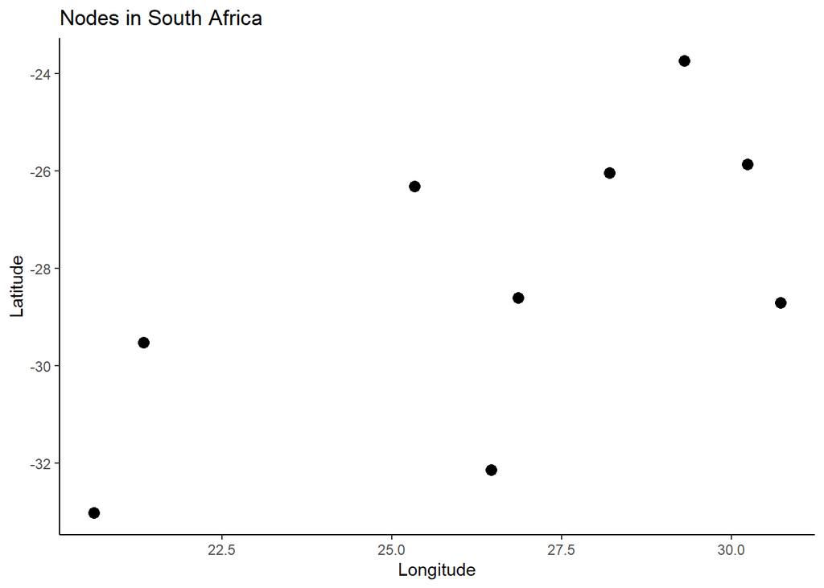

```r
  ## Visualize node distribution
ggplot(ZAF_nodes) +
  geom_point(aes(x = lon, y = lat), color = "black", size = 3) +
  labs(title = "Nodes in South Africa",
       x = "Longitude", y = "Latitude") +
  theme_classic()
```

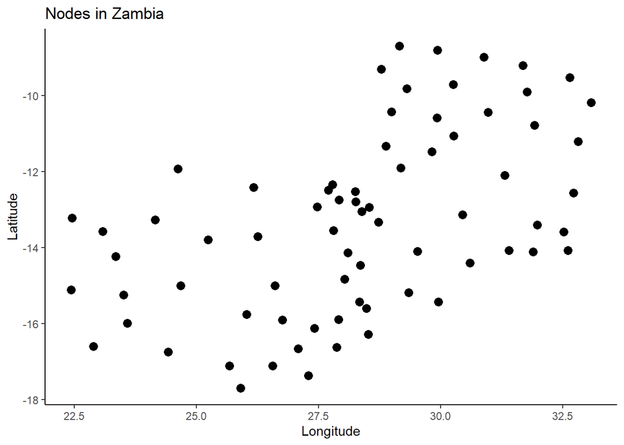

```r
ggplot(ZMB_nodes) +
  geom_point(aes(x = lon, y = lat), color = "black", size = 3) +
  labs(title = "Nodes in Zambia",
       x = "Longitude", y = "Latitude") +
  theme_classic()
```

```r
  ## Load shapefiles
ZAF_shp <- st_read("data/geoBoundaries-ZAF-ADM1.shp")
ZMB_shp <- st_read("data/geoBoundaries-ZMB-ADM1.shp")
glimpse(ZAF_shp)
```

```
## Rows: 9
## Columns: 6
## $ shapeName  <chr> "Eastern Cape", "Free State", "Gauteng", "KwaZulu-Natal", "…
## $ shapeISO   <chr> "EC", "FS", "GT", "KZ", "LI", "MP", "NW", "NC", "WC"
## $ shapeID    <chr> "76434192B98113213215773", "76434192B57942368908249", "7643…
## $ shapeGroup <chr> "ZAF", "ZAF", "ZAF", "ZAF", "ZAF", "ZAF", "ZAF", "ZAF", "ZA…
## $ shapeType  <chr> "ADM1", "ADM1", "ADM1", "ADM1", "ADM1", "ADM1", "ADM1", "AD…
## $ geometry   <MULTIPOLYGON [°]> MULTIPOLYGON (((30.19386 -3..., MULTIPOLYGON (((27.37735 -3…
```

```r
glimpse(ZMB_shp)
```

```
## Rows: 10
## Columns: 6
## $ shapeName  <chr> "Eastern", "Muchinga", "North-Western", "Luapula", "Central…
## $ shapeISO   <chr> "ZM-03", "ZM-10", "ZM-06", "ZM-04", "ZM-02", "ZM-07", "ZM-0…
## $ shapeID    <chr> "6923714B50523150920038", "6923714B61233419501629", "692371…
## $ shapeGroup <chr> "ZMB", "ZMB", "ZMB", "ZMB", "ZMB", "ZMB", "ZMB", "ZMB", "ZM…
## $ shapeType  <chr> "ADM1", "ADM1", "ADM1", "ADM1", "ADM1", "ADM1", "ADM1", "AD…
## $ geometry   <POLYGON [°]> POLYGON ((30.2157 -14.99794..., POLYGON ((33.22481 …
```

```r
  ## Transform nodes for spatial matching
ZAF_nodes_sf <- st_as_sf(ZAF_nodes, coords = c("lon", "lat"), crs = st_crs(ZAF_shp))
ZAF_matched_nodes <- st_join(ZAF_nodes_sf, ZAF_shp)
ZMB_nodes_sf <- st_as_sf(ZMB_nodes, coords = c("lon", "lat"), crs = st_crs(ZMB_shp))
ZMB_matched_nodes <- st_join(ZMB_nodes_sf, ZMB_shp)
  ## Export matched data with coordinates
table(ZAF_matched_nodes$shapeName)
```

```
##
##  Eastern Cape    Free State       Gauteng KwaZulu-Natal       Limpopo
##             1             1             1             1             1
##    Mpumalanga    North West  Nothern Cape  Western Cape
##             1             1             1             1
```

```r
table(ZMB_matched_nodes$shapeName)
```

```
##
##       Central    Copperbelt       Eastern       Luapula        Lusaka
##             7            10             7             7             4
##      Muchinga North-Western      Northern      Southern       Western
##             5             7             8            10             7
```

```r
# Matching is complete. However, in Zambia, several data points are aggregated at higher-level provincial administrative units. Since this study focuses on inter-provincial migration in both countries, subsequent analysis must exclude intra-provincial flows.
```

```r
 ## Clean migration flow data and perform spatial matching
ZAF_migration_flows <- ZAF %>%
  select(NODEI, NODEJ, LONFR, LATFR, LONTO, LATTO, PrdMIG)
ZMB_migration_flows <- ZMB %>%
  select(NODEI, NODEJ, LONFR, LATFR, LONTO, LATTO, PrdMIG)
ZAF_starting_points <- ZAF_migration_flows %>%
  st_as_sf(coords = c("LONFR", "LATFR"), crs = st_crs(ZAF_shp))
ZAF_ending_points <- ZAF_migration_flows %>%
  st_as_sf(coords = c("LONTO", "LATTO"), crs = st_crs(ZAF_shp))
ZMB_starting_points <- ZMB_migration_flows %>%
  st_as_sf(coords = c("LONFR", "LATFR"), crs = st_crs(ZMB_shp))
ZMB_ending_points <- ZMB_migration_flows %>%
  st_as_sf(coords = c("LONTO", "LATTO"), crs = st_crs(ZMB_shp))
ZAF_starting_points <- st_join(ZAF_starting_points, ZAF_shp)
ZAF_ending_points <- st_join(ZAF_ending_points, ZAF_shp)
ZMB_starting_points <- st_join(ZMB_starting_points, ZMB_shp)
ZMB_ending_points <- st_join(ZMB_ending_points, ZMB_shp)
ZAF_migration_flows <- ZAF_migration_flows %>%
  mutate(
    Province_From = ZAF_starting_points$shapeName,
    Province_To = ZAF_ending_points$shapeName
  )
ZMB_migration_flows <- ZMB_migration_flows %>%
  mutate(
    Province_From = ZMB_starting_points$shapeName,
    Province_To = ZMB_ending_points$shapeName
  )
  ## Clean duplicate data for South Africa
ZAF_migration_flows <- ZAF_migration_flows %>%
  filter(`Province_From` != `Province_To`) %>%
  glimpse()
```

```
## Rows: 72
## Columns: 9
## $ NODEI         <dbl> 2, 3, 4, 5, 6, 7, 8, 9, 1, 3, 4, 5, 6, 7, 8, 9, 1, 2, 4,…
## $ NODEJ         <dbl> 1, 1, 1, 1, 1, 1, 1, 1, 2, 2, 2, 2, 2, 2, 2, 2, 3, 3, 3,…
## $ LONFR         <dbl> 26.46742, 21.34706, 26.86447, 30.72498, 25.33597, 28.209…
## $ LATFR         <dbl> -32.14189, -29.52580, -28.61012, -28.70839, -26.31898, -…
## $ LONTO         <dbl> 20.61418, 20.61418, 20.61418, 20.61418, 20.61418, 20.614…
## $ LATTO         <dbl> -33.01144, -33.01144, -33.01144, -33.01144, -33.01144, -…
## $ PrdMIG        <dbl> 2242.5781, 1715.8714, 960.1820, 1524.7384, 1068.5179, 21…
## $ Province_From <chr> "Eastern Cape", "Nothern Cape", "Free State", "KwaZulu-N…
## $ Province_To   <chr> "Western Cape", "Western Cape", "Western Cape", "Western…
```

```r
  ## Clean intra-provincial and inter-provincial migration flows for Zambia
ZMB_migration_flows.intra <- ZMB_migration_flows %>%
  filter(`Province_From` == `Province_To`)
ZMB_migration_flows <- ZMB_migration_flows %>%
  filter(`Province_From` != `Province_To`) %>%
  glimpse()
```

```
## Rows: 4,634
## Columns: 9
## $ NODEI         <dbl> 201, 202, 203, 204, 205, 206, 207, 208, 209, 210, 301, 3…
## $ NODEJ         <dbl> 101, 101, 101, 101, 101, 101, 101, 101, 101, 101, 101, 1…
## $ LONFR         <dbl> 27.78018, 27.69583, 27.91583, 28.25840, 28.38552, 27.471…
## $ LATFR         <dbl> -12.343630, -12.486254, -12.741161, -12.789234, -13.0480…
## $ LONTO         <dbl> 28.03562, 28.03562, 28.03562, 28.03562, 28.03562, 28.035…
## $ LATTO         <dbl> -14.83439, -14.83439, -14.83439, -14.83439, -14.83439, -…
## $ PrdMIG        <dbl> 457.8132, 698.1624, 508.1001, 1208.1467, 839.9981, 501.0…
## $ Province_From <chr> "Copperbelt", "Copperbelt", "Copperbelt", "Copperbelt", …
## $ Province_To   <chr> "Central", "Central", "Central", "Central", "Central", "…
```

```r
  ## Preview
head(ZAF_migration_flows)
```

```
## # A tibble: 6 × 9
##   NODEI NODEJ LONFR LATFR LONTO LATTO PrdMIG Province_From Province_To
##   <dbl> <dbl> <dbl> <dbl> <dbl> <dbl>  <dbl> <chr>         <chr>
## 1     2     1  26.5 -32.1  20.6 -33.0  2243. Eastern Cape  Western Cape
## 2     3     1  21.3 -29.5  20.6 -33.0  1716. Nothern Cape  Western Cape
## 3     4     1  26.9 -28.6  20.6 -33.0   960. Free State    Western Cape
## 4     5     1  30.7 -28.7  20.6 -33.0  1525. KwaZulu-Natal Western Cape
## 5     6     1  25.3 -26.3  20.6 -33.0  1069. North West    Western Cape
## 6     7     1  28.2 -26.0  20.6 -33.0  2146. Gauteng       Western Cape
```

```r
str(ZAF_migration_flows)
```

```
## tibble [72 × 9] (S3: tbl_df/tbl/data.frame)
##  $ NODEI        : num [1:72] 2 3 4 5 6 7 8 9 1 3 ...
##  $ NODEJ        : num [1:72] 1 1 1 1 1 1 1 1 2 2 ...
##  $ LONFR        : num [1:72] 26.5 21.3 26.9 30.7 25.3 ...
##  $ LATFR        : num [1:72] -32.1 -29.5 -28.6 -28.7 -26.3 ...
##  $ LONTO        : num [1:72] 20.6 20.6 20.6 20.6 20.6 ...
##  $ LATTO        : num [1:72] -33 -33 -33 -33 -33 ...
##  $ PrdMIG       : num [1:72] 2243 1716 960 1525 1069 ...
##  $ Province_From: chr [1:72] "Eastern Cape" "Nothern Cape" "Free State" "KwaZulu-Natal" ...
##  $ Province_To  : chr [1:72] "Western Cape" "Western Cape" "Western Cape" "Western Cape" ...
```

```r
head(ZMB_migration_flows)
```

```
## # A tibble: 6 × 9
##   NODEI NODEJ LONFR LATFR LONTO LATTO PrdMIG Province_From Province_To
##   <dbl> <dbl> <dbl> <dbl> <dbl> <dbl>  <dbl> <chr>         <chr>
## 1   201   101  27.8 -12.3  28.0 -14.8   458. Copperbelt    Central
## 2   202   101  27.7 -12.5  28.0 -14.8   698. Copperbelt    Central
## 3   203   101  27.9 -12.7  28.0 -14.8   508. Copperbelt    Central
## 4   204   101  28.3 -12.8  28.0 -14.8  1208. Copperbelt    Central
## 5   205   101  28.4 -13.0  28.0 -14.8   840. Copperbelt    Central
## 6   206   101  27.5 -12.9  28.0 -14.8   501. Copperbelt    Central
```

```r
str(ZMB_migration_flows)
```

```
## tibble [4,634 × 9] (S3: tbl_df/tbl/data.frame)
##  $ NODEI        : num [1:4634] 201 202 203 204 205 206 207 208 209 210 ...
##  $ NODEJ        : num [1:4634] 101 101 101 101 101 101 101 101 101 101 ...
##  $ LONFR        : num [1:4634] 27.8 27.7 27.9 28.3 28.4 ...
##  $ LATFR        : num [1:4634] -12.3 -12.5 -12.7 -12.8 -13 ...
##  $ LONTO        : num [1:4634] 28 28 28 28 28 ...
##  $ LATTO        : num [1:4634] -14.8 -14.8 -14.8 -14.8 -14.8 ...
##  $ PrdMIG       : num [1:4634] 458 698 508 1208 840 ...
##  $ Province_From: chr [1:4634] "Copperbelt" "Copperbelt" "Copperbelt" "Copperbelt" ...
##  $ Province_To  : chr [1:4634] "Central" "Central" "Central" "Central" ...
```

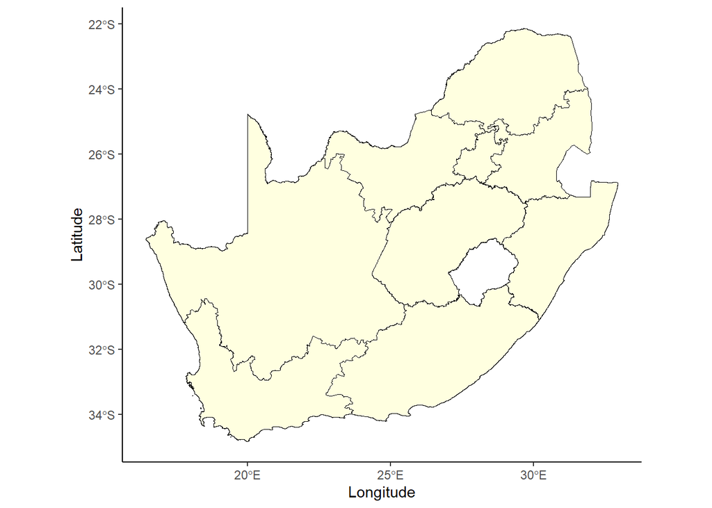

```r
  ## Define the study area
ggplot() +
  geom_sf(data = ZAF_shp, fill = "lightyellow", color = "black") +
  labs(x = "Longitude", y = "Latitude") +
  theme_classic()
```

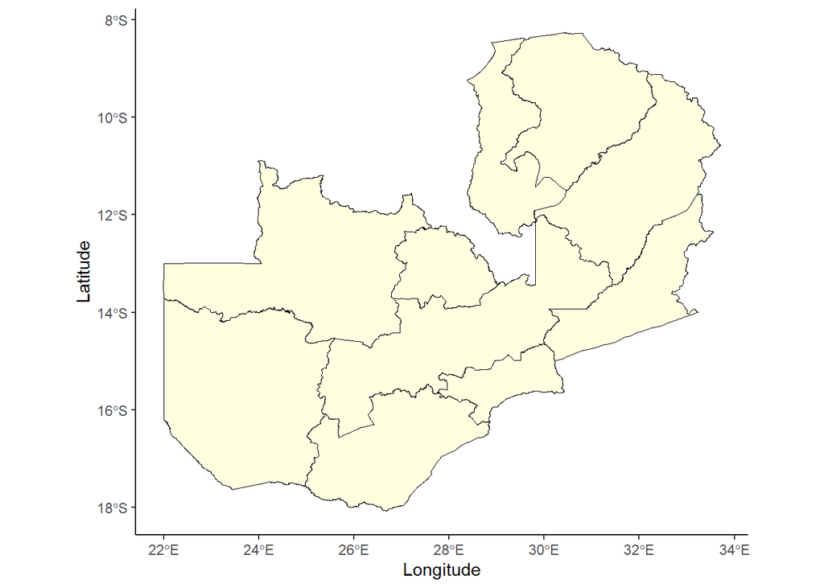

```r
ggplot() +
  geom_sf(data = ZMB_shp, fill = "lightyellow", color = "black") +
  labs(x = "Longitude", y = "Latitude") +
  theme_classic()
```

5. Study area and data

5.1 Research field

The focus of this study is on South Africa and Zambia, also South of the Sahara, which have very different socio-economic backgrounds and migration dynamics, which are comparable, and also because of what I know from the <World Malaria Report 2015>: “Until 2015, the majority of cases continued to occur in the WHO African region (88%), and the global mortality burden was dominated by countries in sub-Saharan Africa. The continued threat of malaria posed a serious public health challenge in both countries in 2005-2010.” Migration may be a key way to address this challenge, and destination cities may offer better medical resources and chances of survival. Using South Africa and Zambia as control groups, the research through the space network analysis discusses the migration patterns and the connection between social economy and health factors.

```r
  ## Clean variable data
ZAF_HDI <- read.csv("data/ZAF_HDI.csv")
ZMB_HDI <- read.csv("data/ZMB_HDI.csv")
ZAF_Malaria <- read.csv("data/ZAF_Malaria.csv")
ZMB_Malaria <- read.csv("data/ZMB_Malaria.csv")
ZAF_Population <- read.csv("data/ZAF_Population.csv")
ZMB_Population <- read.csv("data/ZMB_Population.csv")
str(ZAF_HDI)
```

```
## 'data.frame':    9 obs. of  8 variables:
##  $ Country  : chr  "South Africa" "South Africa" "South Africa" "South Africa" ...
##  $ Continent: chr  "Africa" "Africa" "Africa" "Africa" ...
##  $ ISO_Code : chr  "ZAF" "ZAF" "ZAF" "ZAF" ...
##  $ Level    : chr  "Subnat" "Subnat" "Subnat" "Subnat" ...
##  $ GDLCODE  : chr  "ZAFr102" "ZAFr104" "ZAFr107" "ZAFr105" ...
##  $ Region   : chr  "Eastern Cape" "Free State" "Gauteng" "KwaZulu Natal" ...
##  $ X2005    : num  0.586 0.637 0.681 0.604 0.608 0.615 0.618 0.612 0.689
##  $ X2010    : num  0.631 0.672 0.714 0.656 0.649 0.648 0.655 0.664 0.717
```

```r
head(ZAF_HDI)
```

```
##        Country Continent ISO_Code  Level GDLCODE        Region X2005 X2010
## 1 South Africa    Africa      ZAF Subnat ZAFr102  Eastern Cape 0.586 0.631
## 2 South Africa    Africa      ZAF Subnat ZAFr104    Free State 0.637 0.672
## 3 South Africa    Africa      ZAF Subnat ZAFr107       Gauteng 0.681 0.714
## 4 South Africa    Africa      ZAF Subnat ZAFr105 KwaZulu Natal 0.604 0.656
## 5 South Africa    Africa      ZAF Subnat ZAFr108    Mpumalanga 0.608 0.649
## 6 South Africa    Africa      ZAF Subnat ZAFr106    North West 0.615 0.648
```

```r
str(ZMB_HDI)
```

```
## 'data.frame':    10 obs. of  8 variables:
##  $ Country  : chr  "Zambia" "Zambia" "Zambia" "Zambia" ...
##  $ Continent: chr  "Africa" "Africa" "Africa" "Africa" ...
##  $ ISO_Code : chr  "ZMB" "ZMB" "ZMB" "ZMB" ...
##  $ Level    : chr  "Subnat" "Subnat" "Subnat" "Subnat" ...
##  $ GDLCODE  : chr  "ZMBr101" "ZMBr102" "ZMBr103" "ZMBr104" ...
##  $ Region   : chr  "Central" "Copperbelt" "Eastern" "Luapula" ...
##  $ X2005    : num  0.473 0.545 0.421 0.418 0.54 0.461 0.433 0.482 0.408 0
##  $ X2010    : num  0.525 0.601 0.463 0.479 0.602 0.508 0.482 0.542 0.47 0
```

```r
head(ZMB_HDI)
```

```
##   Country Continent ISO_Code  Level GDLCODE        Region X2005 X2010
## 1  Zambia    Africa      ZMB Subnat ZMBr101       Central 0.473 0.525
## 2  Zambia    Africa      ZMB Subnat ZMBr102    Copperbelt 0.545 0.601
## 3  Zambia    Africa      ZMB Subnat ZMBr103       Eastern 0.421 0.463
## 4  Zambia    Africa      ZMB Subnat ZMBr104       Luapula 0.418 0.479
## 5  Zambia    Africa      ZMB Subnat ZMBr105        Lusaka 0.540 0.602
## 6  Zambia    Africa      ZMB Subnat ZMBr107 North-Western 0.461 0.508
```

```r
str(ZAF_Malaria)
```

```
## 'data.frame':    3 obs. of  4 variables:
##  $ Country   : chr  "South Africa" "South Africa" "South Africa"
##  $ Region    : chr  "KwaZulu Natal" "Limpopo" "Mpumalanga"
##  $ Cases.2005: int  41786 9487 12390
##  $ Cases.2010: int  380 4174 2187
```

```r
head(ZAF_Malaria)
```

```
##        Country        Region Cases.2005 Cases.2010
## 1 South Africa KwaZulu Natal      41786        380
## 2 South Africa       Limpopo       9487       4174
## 3 South Africa    Mpumalanga      12390       2187
```

```r
str(ZMB_Malaria)
```

```
## 'data.frame':    10 obs. of  4 variables:
##  $ Country               : chr  "Zambia" "Zambia" "Zambia" "Zambia" ...
##  $ Region                : chr  "Central" "Copperbelt" "Eastern" "Luapula" ...
##  $ Malaria.Incidence.2005: int  390621 686307 674760 367825 494468 226194 634675 484157 371195 0
##  $ Malaria.Incidence.2010: int  2190 3380 2920 1815 3200 2860 1130 2740 1575 0
```

```r
head(ZMB_Malaria)
```

```
##   Country     Region Malaria.Incidence.2005 Malaria.Incidence.2010
## 1  Zambia    Central                 390621                   2190
## 2  Zambia Copperbelt                 686307                   3380
## 3  Zambia    Eastern                 674760                   2920
## 4  Zambia    Luapula                 367825                   1815
## 5  Zambia     Lusaka                 494468                   3200
## 6  Zambia   Northern                 226194                   2860
```

```r
str(ZAF_Population)
```

```
## 'data.frame':    9 obs. of  4 variables:
##  $ Country    : chr  "South Africa" "South Africa" "South Africa" "South Africa" ...
##  $ Region     : chr  "Eastern Cape" "Free State" "Gauteng" "KwaZulu Natal" ...
##  $ Census.2005: int  6527747 2773059 10451713 10259230 5238286 3643435 1058060 3271948 5278585
##  $ Census.2010: int  6562053 2745590 12272263 10267300 5404868 4039939 1145861 3509953 5822734
```

```r
head(ZAF_Population)
```

```
##        Country        Region Census.2005 Census.2010
## 1 South Africa  Eastern Cape     6527747     6562053
## 2 South Africa    Free State     2773059     2745590
## 3 South Africa       Gauteng    10451713    12272263
## 4 South Africa KwaZulu Natal    10259230    10267300
## 5 South Africa       Limpopo     5238286     5404868
## 6 South Africa    Mpumalanga     3643435     4039939
```

```r
str(ZMB_Population)
```

```
## 'data.frame':    10 obs. of  4 variables:
##  $ Country    : chr  "Zambia" "Zambia" "Zambia" "Zambia" ...
##  $ Region     : chr  "Central" "Copperbelt" "Eastern" "Luapula" ...
##  $ Census.2005: int  1180124 1820443 1509530 903746 1579769 666266 683367 1445730 1407433 863244
##  $ Census.2010: int  1307111 1972317 1592661 991927 2191225 711657 727044 1105824 1589926 902974
```

```r
head(ZMB_Population)
```

```
##   Country     Region Census.2005 Census.2010
## 1  Zambia    Central     1180124     1307111
## 2  Zambia Copperbelt     1820443     1972317
## 3  Zambia    Eastern     1509530     1592661
## 4  Zambia    Luapula      903746      991927
## 5  Zambia     Lusaka     1579769     2191225
## 6  Zambia   Muchinga      666266      711657
```

```r
# Malaria cases in South Africa are well-controlled. The study only includes the three provinces with the highest number of cases.
```

```r
  ## Merge data
ZAF_Influential_Variables <- left_join(ZAF_HDI, ZAF_Malaria, by = "Region")
ZAF_Influential_Variables <- left_join(ZAF_Influential_Variables, ZAF_Population, by = "Region")
ZMB_Influential_Variables <- left_join(ZMB_HDI, ZMB_Malaria, by = "Region")
ZMB_Influential_Variables <- left_join(ZMB_Influential_Variables, ZMB_Population, by = "Region")
```

```r
  ## Check South African data and merge the results
head(ZAF_Influential_Variables)
```

```
##      Country.x Continent ISO_Code  Level GDLCODE        Region X2005 X2010
## 1 South Africa    Africa      ZAF Subnat ZAFr102  Eastern Cape 0.586 0.631
## 2 South Africa    Africa      ZAF Subnat ZAFr104    Free State 0.637 0.672
## 3 South Africa    Africa      ZAF Subnat ZAFr107       Gauteng 0.681 0.714
## 4 South Africa    Africa      ZAF Subnat ZAFr105 KwaZulu Natal 0.604 0.656
## 5 South Africa    Africa      ZAF Subnat ZAFr108    Mpumalanga 0.608 0.649
## 6 South Africa    Africa      ZAF Subnat ZAFr106    North West 0.615 0.648
##      Country.y Cases.2005 Cases.2010      Country Census.2005 Census.2010
## 1         <NA>         NA         NA South Africa     6527747     6562053
## 2         <NA>         NA         NA South Africa     2773059     2745590
## 3         <NA>         NA         NA South Africa    10451713    12272263
## 4 South Africa      41786        380 South Africa    10259230    10267300
## 5 South Africa      12390       2187 South Africa     3643435     4039939
## 6         <NA>         NA         NA South Africa     3271948     3509953
```

```r
ZAF_Influential_Variables <- ZAF_Influential_Variables %>%
  select(Country = `Country.x`,
         ISO_Code,
         Region,
         HDI2005 = `X2005`,
         HDI2010 = `X2010`,
         Malaria2005 = `Cases.2005`,
         Malaria2010 = `Cases.2010`,
         Pop2005 = `Census.2005`,
         Pop2010 = `Census.2010`) %>%
  filter(HDI2005 != 0, HDI2010 != 0, Pop2005 != 0, Pop2010 != 0)
  ## Handle NA values
ZAF_Influential_Variables <- ZAF_Influential_Variables %>%
  mutate(across(c(Malaria2005, Malaria2010), ~ replace_na(., 0)))

# South Africa has some missing data, South Africa's data frame contains some missing values (NAs), which should be carefully assessed and addressed during the analysis.
```

```r
  ## Check Zambian data and merge the results
head(ZMB_Influential_Variables)
```

```
##   Country.x Continent ISO_Code  Level GDLCODE        Region X2005 X2010
## 1    Zambia    Africa      ZMB Subnat ZMBr101       Central 0.473 0.525
## 2    Zambia    Africa      ZMB Subnat ZMBr102    Copperbelt 0.545 0.601
## 3    Zambia    Africa      ZMB Subnat ZMBr103       Eastern 0.421 0.463
## 4    Zambia    Africa      ZMB Subnat ZMBr104       Luapula 0.418 0.479
## 5    Zambia    Africa      ZMB Subnat ZMBr105        Lusaka 0.540 0.602
## 6    Zambia    Africa      ZMB Subnat ZMBr107 North-Western 0.461 0.508
##   Country.y Malaria.Incidence.2005 Malaria.Incidence.2010 Country Census.2005
## 1    Zambia                 390621                   2190  Zambia     1180124
## 2    Zambia                 686307                   3380  Zambia     1820443
## 3    Zambia                 674760                   2920  Zambia     1509530
## 4    Zambia                 367825                   1815  Zambia      903746
## 5    Zambia                 494468                   3200  Zambia     1579769
## 6    Zambia                 634675                   1130  Zambia      683367
##   Census.2010
## 1     1307111
## 2     1972317
## 3     1592661
## 4      991927
## 5     2191225
## 6      727044
```

```r
ZMB_Influential_Variables <- ZMB_Influential_Variables %>%
  select(Country = `Country.x`,
         ISO_Code,
         Region,
         HDI2005 = `X2005`,
         HDI2010 = `X2010`,
         Malaria2005 = `Malaria.Incidence.2005`,
         Malaria2010 = `Malaria.Incidence.2010`,
         Pop2005 = `Census.2005`,
         Pop2010 = `Census.2010`) %>%
  filter(HDI2005 != 0, HDI2010 != 0, Malaria2005 != 0, Malaria2010 != 0)

# Exclude Muchinga province from the analysis as no data is available for this province
```

6.Methods

6.1 Network Construction The migration network is constructed by defining provinces as nodes and migration flows as weighted directed edges. The network is visualized to illustrate the spatial pattern of migration. Centrality measures including weighted degree, betweenness, eigenvector centrality, and PageRank are computed to determine the importance of each province in the migration network.

6.2 Simple correlation analysis In order to explore the relationship between migration flows and key variables, we conducted a simple correlation analysis and applied Spearman and Kendall correlation tests to evaluate the relationship between immigration intensity and various variable factors.

6.3 Regression model Regression models (OLS, Gamma) assess the degree of correlation between the migration flow and explanatory variables. The Gamma regression model was chosen to construct a regression model together with the push-pull theory to analyze the influence of variable changes on the migration flow.

7. Coding Output

```r
#3. Visualizing Migration Flow Data
  ## South Africa Migration Flows: Convert to 'sf' objects
st_crs(ZAF_migration_flows)
```

```
## Coordinate Reference System: NA
```

```r
ZAF_migration_flows$geometry <- mapply(
  function(lon_fr, lat_fr, lon_to, lat_to) {
    st_linestring(matrix(c(lon_fr, lon_to, lat_fr, lat_to), ncol = 2))
  },
  ZAF_migration_flows$LONFR, ZAF_migration_flows$LATFR,
  ZAF_migration_flows$LONTO, ZAF_migration_flows$LATTO,
  SIMPLIFY = F
)
ZAF_migration_flows <- st_sf(ZAF_migration_flows, crs = 4326)
st_crs(ZAF_migration_flows)
```

[output not shown]

```r
head(ZAF_migration_flows$geometry)
```

```
## Geometry set for 6 features
## Geometry type: LINESTRING
## Dimension:     XY
## Bounding box:  xmin: 20.61418 ymin: -33.01144 xmax: 30.72498 ymax: -26.0453
## Geodetic CRS:  WGS 84
## First 5 geometries:
```

```
## LINESTRING (26.46742 -32.14189, 20.61418 -33.01...
```

```
## LINESTRING (21.34706 -29.5258, 20.61418 -33.01144)
```

```
## LINESTRING (26.86447 -28.61012, 20.61418 -33.01...
```

```
## LINESTRING (30.72498 -28.70839, 20.61418 -33.01...
```

```
## LINESTRING (25.33597 -26.31898, 20.61418 -33.01...
```

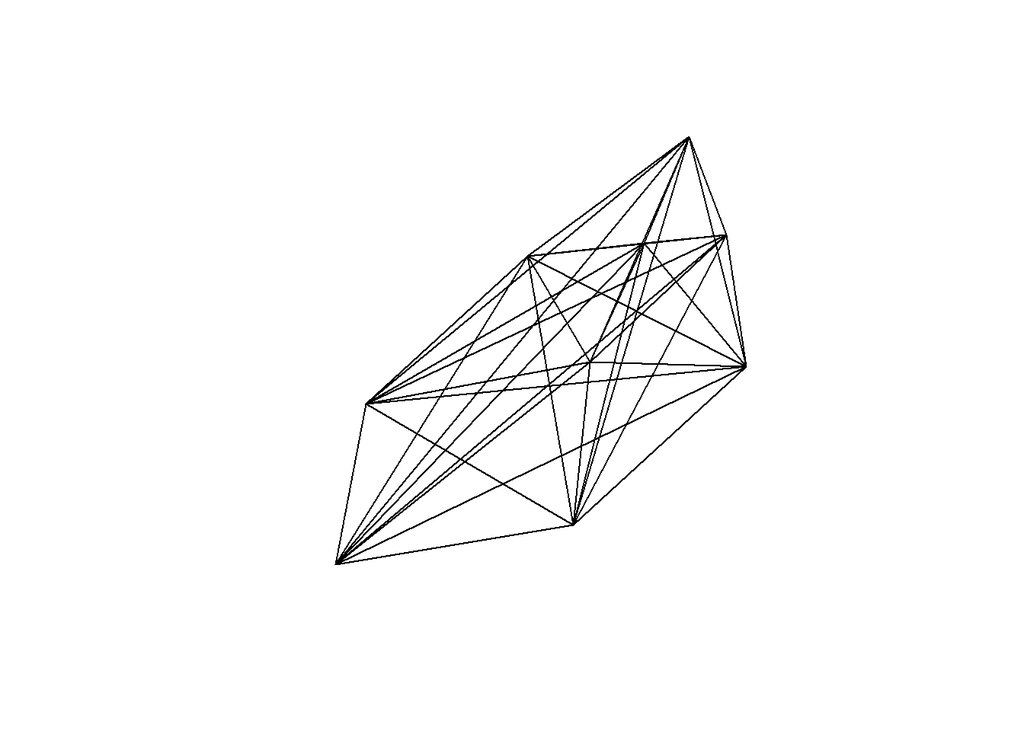

```r
plot(ZAF_migration_flows["geometry"])
```

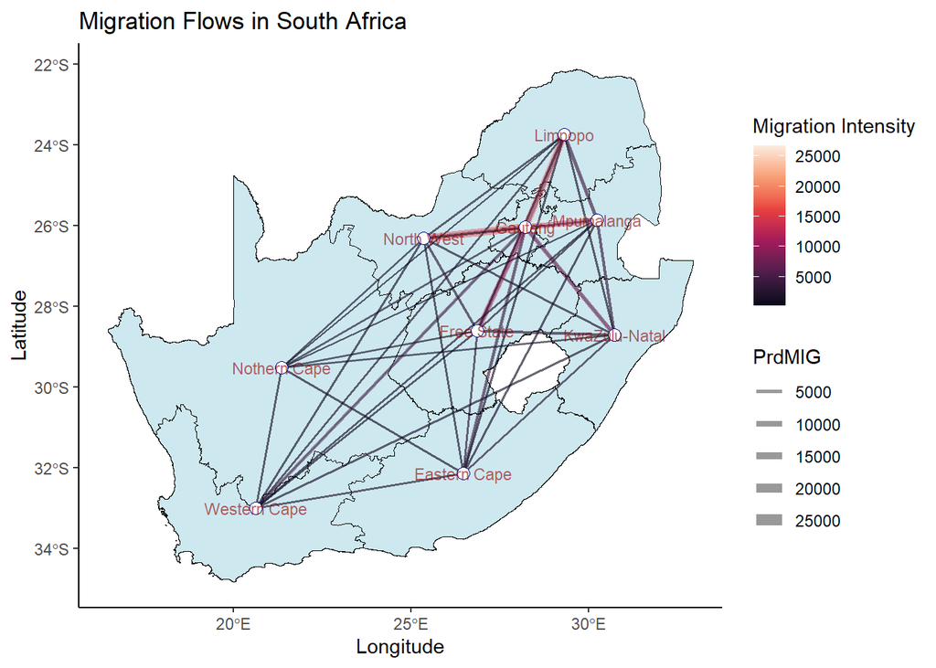

```r
  ## Ensure CRS consistency
ZAF_shp0 <- st_transform(ZAF_shp, crs = 4326)
ZAF_matched_nodes0<- st_transform(ZAF_matched_nodes, crs = st_crs(ZAF_shp0))
  ## Set thresholds
ZAF_migration_flows1 <- ZAF_migration_flows[ZAF_migration_flows$PrdMIG > 200, ]
ggplot() +
  geom_sf(data = ZAF_shp0, fill = "lightblue", color = "black", linewidth = 0.2, alpha = 0.6) +
  geom_segment(data = ZAF_migration_flows1,
               aes(x = LONFR, y = LATFR,
                   xend = LONTO, yend = LATTO,
                   color = PrdMIG, linewidth = PrdMIG),
               alpha = 0.4) +
  scale_color_viridis_c(option = "F") +
  ## Use the scale_fill_viridis_d function to create a colorblind-friendly visualization, as recommended in Harvard's CS50R: Introduction to R Programming (2024).
  scale_linewidth_continuous(range = c(0.5, 3)) +
  geom_sf(data = ZAF_matched_nodes0, color = "darkblue", size = 3, shape = 21, fill = "white") +
  geom_sf_text(data = ZAF_matched_nodes0, aes(label = shapeName), size = 3, color = "darkred", alpha = 0.6) +
  labs(
    title = "Migration Flows in South Africa",
    x = "Longitude", y = "Latitude",
    color = "Migration Intensity",
    size = "Migration Intensity"
  ) +
  theme_classic()
```

```r
# Warning Note: The warning regarding st_point_on_surface is caused by the use of a geographic CRS (WGS 84). While this issue can be resolved by transforming the data to a projected CRS (e.g., UTM), it does not significantly impact the analysis in this case as the labels are approximate. Therefore, the warning is noted but intentionally ignored for this visualization.
```

The migration of South Africa shows a relatively obvious trend. The main migration routes are concentrated in the eastern provinces such as Limpopo, Gauteng and KwaZulu-Natal. In contrast, there has been relatively little migration activity in the western region. Gauteng Province has the potential to play a key role as a hub central node in South Africa’s migration network.

```r
  ## Zambia Migration Flows: Convert to 'sf' objects
st_crs(ZMB_migration_flows)
```

```
## Coordinate Reference System: NA
```

```r
ZMB_migration_flows$geometry <- mapply(
  function(lon_fr, lat_fr, lon_to, lat_to) {
    st_linestring(matrix(c(lon_fr, lon_to, lat_fr, lat_to), ncol = 2))
  },
  ZMB_migration_flows$LONFR, ZMB_migration_flows$LATFR,
  ZMB_migration_flows$LONTO, ZMB_migration_flows$LATTO,
  SIMPLIFY = F
)
ZMB_migration_flows <- st_sf(ZMB_migration_flows, crs = 4326)
st_crs(ZMB_migration_flows)
```

[output not shown]

```r
head(ZMB_migration_flows$geometry)
```

```
## Geometry set for 6 features
## Geometry type: LINESTRING
## Dimension:     XY
## Bounding box:  xmin: 27.4713 ymin: -14.83439 xmax: 28.38552 ymax: -12.34363
## Geodetic CRS:  WGS 84
## First 5 geometries:
```

```
## LINESTRING (27.78018 -12.34363, 28.03562 -14.83...
```

```
## LINESTRING (27.69583 -12.48625, 28.03562 -14.83...
```

```
## LINESTRING (27.91583 -12.74116, 28.03562 -14.83...
```

```
## LINESTRING (28.2584 -12.78923, 28.03562 -14.83439)
```

```
## LINESTRING (28.38552 -13.04802, 28.03562 -14.83...
```

[figure not shown]

```r
plot(ZMB_migration_flows["geometry"])
```

```r
  ## Ensure CRS consistency
ZMB_shp0 <- st_transform(ZMB_shp, crs = 4326)
ZMB_matched_nodes0<- st_transform(ZMB_matched_nodes, crs = st_crs(ZMB_shp0))
  ## Extract unique values for provincial labels
Province_labels <- ZMB_matched_nodes0 %>%
  group_by(shapeName) %>%
  summarise(geometry = first(geometry), .groups = "drop")
  ## Check
glimpse(Province_labels)
```

```
## Rows: 10
## Columns: 2
## $ shapeName <chr> "Central", "Copperbelt", "Eastern", "Luapula", "Lusaka", "Mu…
## $ geometry  <POINT [°]> POINT (28.35282 -14.47035), POINT (27.78018 -12.34363)…
```

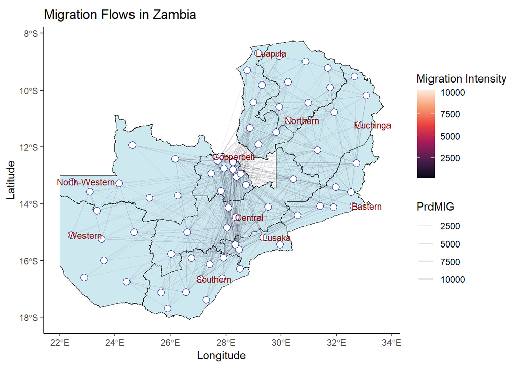

```r
  ## Set thresholds
ZMB_migration_flows1 <- ZMB_migration_flows[ZMB_migration_flows$PrdMIG > 200, ]
ggplot() +
  geom_sf(data = ZMB_shp0, fill = "lightblue", color = "black", linewidth = 0.2, alpha = 0.6) +  ## Plot the map of South Africa
  geom_segment(data = ZMB_migration_flows1,
               aes(x = LONFR, y = LATFR,
                   xend = LONTO, yend = LATTO,
                   color = PrdMIG, linewidth = PrdMIG),
               alpha = 0.1) +
  scale_color_viridis_c(option = "F") +
  scale_linewidth_continuous(range = c(0.1, 1)) +
  geom_sf(data = ZMB_matched_nodes0, color = "darkblue", size = 3, shape = 21, fill = "white") +
  geom_sf_text(data = Province_labels, aes(label = shapeName), size = 3, color = "darkred", nudge_x = 0.5) +
  labs(
    title = "Migration Flows in Zambia",
    x = "Longitude", y = "Latitude",
    color = "Migration Intensity",
    size = "Migration Intensity"
  ) +
  theme_classic()
```

```r
# Warning Note: The warning regarding st_point_on_surface is caused by the use of a geographic CRS (WGS 84). While this issue can be resolved by transforming the data to a projected CRS (e.g., UTM), it does not significantly impact the analysis in this case as the labels are approximate. Therefore, the warning is noted but intentionally ignored for this visualization.
```

Compared with South Africa, migration flows in Zambia did not show a strong trend, most likely due to differences in the number of samples tested or the policies of the study nodes. Migration destinations are diverse, with a general tendency toward neighboring provinces or districts. Migration paths are relatively short.

```r
#4. Migration Flow Network Construction And Centrality Calculation
  ## South Africa network construction
ZAF_matched_nodes <- st_as_sf(ZAF_matched_nodes)
ZAF_matched_nodes <- st_transform(ZAF_matched_nodes, crs = st_crs(ZAF_migration_flows))
ZAF_matched_nodes <- ZAF_matched_nodes %>%
  rename(name = NODE)
ZAF_net.all <- graph_from_data_frame(
  d = ZAF_migration_flows %>% rename(weight = PrdMIG),
  directed = T,
  vertices = ZAF_matched_nodes
)

# Use migration flow (PrdMIG) to construct edge weights
```

Due to the absence of weight variables in the base data, this study uses weighted degree centrality to analyze migration flows. This method considers both the number of connections and the weight of connections, reflecting the influence and communication of nodes in the space network. Migration flow (PrdMIG) is used to construct edge weights, enhancing understanding of focal regions in migration flows. This approach has been applied in related research, such as the analysis of interprovincial migration during China’s Spring Festival travel season.(Zhao et al. 2018,)

```r
  ## Check
head(E(ZAF_net.all)$weight)
```

```
## [1] 2242.578 1715.871  960.182 1524.738 1068.518 2145.859
```

```r
  ## calculate different centrality measures
ZAF_w.in.degree <- strength(ZAF_net.all, mode = "in")
ZAF_w.out.degree <- strength(ZAF_net.all, mode = "out")
ZAF_w.degree <- strength(ZAF_net.all, mode = "all")
ZAF_btwnss_weighted <- betweenness(ZAF_net.all, weights = E(ZAF_net.all)$weight, directed = T)
ZAF_eigen <- eigen_centrality(ZAF_net.all, weights = E(ZAF_net.all)$weight)$vector
str(ZAF_eigen)
```

```
##  Named num [1:9] 0.2189 0.0993 0.41 0.36 0.4641 ...
##  - attr(*, "names")= chr [1:9] "2" "3" "4" "5" ...
```

```r
ZAF_prank <- page_rank(ZAF_net.all, directed = T, weights = E(ZAF_net.all)$weight)$vector
str(ZAF_prank)
```

```
##  Named num [1:9] 0.067 0.0326 0.0961 0.0861 0.0983 ...
##  - attr(*, "names")= chr [1:9] "2" "3" "4" "5" ...
```

```r
  # Preview
head(ZAF_w.in.degree)
```

```
##         2         3         4         5         6         7
## 12449.247  3884.453 17430.701 16514.217 16519.851 91557.535
```

```r
head(ZAF_w.out.degree)
```

```
##         2         3         4         5         6         7
## 14650.136  8752.375 23598.047 21043.790 25498.651 36697.947
```

```r
head(ZAF_w.degree)
```

```
##         2         3         4         5         6         7
##  27099.38  12636.83  41028.75  37558.01  42018.50 128255.48
```

```r
head(ZAF_btwnss_weighted)
```

```
##  2  3  4  5  6  7
##  0 34  0  0  1  0
```

```r
head(ZAF_eigen)
```

```
##         2         3         4         5         6         7
## 0.2188905 0.0992635 0.4100467 0.3600254 0.4640675 1.0000000
```

```r
head(ZAF_prank)
```

```
##          2          3          4          5          6          7
## 0.06701775 0.03261123 0.09609694 0.08614497 0.09825148 0.31476316
```

In South Africa’s migration network, the limited number of nodes (9 provinces) results in sparse betweenness distribution. Since this study focuses on node centrality in migration paths, comprehensive metrics are needed. To address potential data extremes, log smoothing was applied to the weighted betweenness index.

```r
  ## Apply log smoothing for output values
ZAF_btwnss_weighted <- log1p(ZAF_btwnss_weighted)
head(ZAF_btwnss_weighted)
```

```
##         2         3         4         5         6         7
## 0.0000000 3.5553481 0.0000000 0.0000000 0.6931472 0.0000000
```

```r
  ## Summarize
ZAF_centralities <- tibble(
  names = vertex_attr(ZAF_net.all, "name"),
  shapeName = vertex_attr(ZAF_net.all, "shapeName"),
  w.in.degree = ZAF_w.in.degree,
  w.out.degree = ZAF_w.out.degree,
  w.degree = ZAF_w.degree,
  btwnss_weighted = ZAF_btwnss_weighted,
  eigen = ZAF_eigen,
  prank = ZAF_prank
)
  ## Preview
head(ZAF_centralities)
```

```
## # A tibble: 6 × 8
##   names shapeName     w.in.degree w.out.degree w.degree btwnss_weighted  eigen
##   <chr> <chr>               <dbl>        <dbl>    <dbl>           <dbl>  <dbl>
## 1 2     Eastern Cape       12449.       14650.   27099.           0     0.219
## 2 3     Nothern Cape        3884.        8752.   12637.           3.56  0.0993
## 3 4     Free State         17431.       23598.   41029.           0     0.410
## 4 5     KwaZulu-Natal      16514.       21044.   37558.           0     0.360
## 5 6     North West         16520.       25499.   42019.           0.693 0.464
## 6 7     Gauteng            91558.       36698.  128255.           0     1
## # ℹ 1 more variable: prank <dbl>
```

```r
  ## Create tables
ZAF_centralities %>%
  kable(caption = "South Africa Centralities") %>%
  scroll_box(width = "100%", height = "300px")
```

South Africa Centralities

| names | shapeName | w.in.degree | w.out.degree | w.degree | btwnss_weighted | eigen | prank |
| --- | --- | --- | --- | --- | --- | --- | --- |
| 2 | Eastern Cape | 12449.247 | 14650.136 | 27099.38 | 0.0000000 | 0.2188905 | 0.0670178 |
| 3 | Nothern Cape | 3884.453 | 8752.375 | 12636.83 | 3.5553481 | 0.0992635 | 0.0326112 |
| 4 | Free State | 17430.701 | 23598.047 | 41028.75 | 0.0000000 | 0.4100467 | 0.0960969 |
| 5 | KwaZulu-Natal | 16514.217 | 21043.790 | 37558.01 | 0.0000000 | 0.3600254 | 0.0861450 |
| 6 | North West | 16519.851 | 25498.651 | 42018.50 | 0.6931472 | 0.4640675 | 0.0982515 |
| 7 | Gauteng | 91557.535 | 36697.947 | 128255.48 | 0.0000000 | 1.0000000 | 0.3147632 |
| 8 | Mpumalanga | 23611.667 | 39720.862 | 63332.53 | 0.0000000 | 0.7362891 | 0.1381736 |
| 9 | Limpopo | 17177.457 | 28182.618 | 45360.08 | 0.0000000 | 0.5296434 | 0.1002536 |
| 1 | Western Cape | 12362.320 | 13363.022 | 25725.34 | 0.0000000 | 0.2173890 | 0.0666872 |

```r
  ## Perform ranking tests
ZAF_test <- ZAF_centralities %>%
  mutate(rank.test = dense_rank(desc(w.in.degree))) %>%
  arrange(rank.test) %>%
  glimpse()
```

```
## Rows: 9
## Columns: 9
## $ names           <chr> "7", "8", "4", "9", "6", "5", "2", "1", "3"
## $ shapeName       <chr> "Gauteng", "Mpumalanga", "Free State", "Limpopo", "Nor…
## $ w.in.degree     <dbl> 91557.535, 23611.667, 17430.701, 17177.457, 16519.851,…
## $ w.out.degree    <dbl> 36697.947, 39720.862, 23598.047, 28182.618, 25498.651,…
## $ w.degree        <dbl> 128255.48, 63332.53, 41028.75, 45360.08, 42018.50, 375…
## $ btwnss_weighted <dbl> 0.0000000, 0.0000000, 0.0000000, 0.0000000, 0.6931472,…
## $ eigen           <dbl> 1.0000000, 0.7362891, 0.4100467, 0.5296434, 0.4640675,…
## $ prank           <dbl> 0.31476316, 0.13817363, 0.09609694, 0.10025359, 0.0982…
## $ rank.test       <int> 1, 2, 3, 4, 5, 6, 7, 8, 9
```

```r
ZAF_ranks <- ZAF_centralities %>%
  mutate_at(vars(w.in.degree:prank),
            list(~ dense_rank(desc(.))))
  ## Modify to ranked versions
colnames(ZAF_ranks) <- paste("r", colnames(ZAF_ranks), sep = "_")
ZAF_combined <- cbind(ZAF_centralities, ZAF_ranks)
glimpse(ZAF_combined)
```

```
## Rows: 9
## Columns: 16
## $ names             <chr> "2", "3", "4", "5", "6", "7", "8", "9", "1"
## $ shapeName         <chr> "Eastern Cape", "Nothern Cape", "Free State", "KwaZu…
## $ w.in.degree       <dbl> 12449.247, 3884.453, 17430.701, 16514.217, 16519.851…
## $ w.out.degree      <dbl> 14650.136, 8752.375, 23598.047, 21043.790, 25498.651…
## $ w.degree          <dbl> 27099.38, 12636.83, 41028.75, 37558.01, 42018.50, 12…
## $ btwnss_weighted   <dbl> 0.0000000, 3.5553481, 0.0000000, 0.0000000, 0.693147…
## $ eigen             <dbl> 0.2188905, 0.0992635, 0.4100467, 0.3600254, 0.464067…
## $ prank             <dbl> 0.06701775, 0.03261123, 0.09609694, 0.08614497, 0.09…
## $ r_names           <chr> "2", "3", "4", "5", "6", "7", "8", "9", "1"
## $ r_shapeName       <chr> "Eastern Cape", "Nothern Cape", "Free State", "KwaZu…
## $ r_w.in.degree     <int> 7, 9, 3, 6, 5, 1, 2, 4, 8
## $ r_w.out.degree    <int> 7, 9, 5, 6, 4, 2, 1, 3, 8
## $ r_w.degree        <int> 7, 9, 5, 6, 4, 1, 2, 3, 8
## $ r_btwnss_weighted <int> 3, 1, 3, 3, 2, 3, 3, 3, 3
## $ r_eigen           <int> 7, 9, 5, 6, 4, 1, 2, 3, 8
## $ r_prank           <int> 7, 9, 5, 6, 4, 1, 2, 3, 8
```

```r
  ## Rank based on weighted degree centrality
ZAF_centralities <- cbind(ZAF_centralities, ZAF_ranks) %>%
  arrange(w.in.degree) %>%
  select(-r_names) %>%
  glimpse()
```

```
## Rows: 9
## Columns: 15
## $ names             <chr> "3", "1", "2", "5", "6", "9", "4", "8", "7"
## $ shapeName         <chr> "Nothern Cape", "Western Cape", "Eastern Cape", "Kwa…
## $ w.in.degree       <dbl> 3884.453, 12362.320, 12449.247, 16514.217, 16519.851…
## $ w.out.degree      <dbl> 8752.375, 13363.022, 14650.136, 21043.790, 25498.651…
## $ w.degree          <dbl> 12636.83, 25725.34, 27099.38, 37558.01, 42018.50, 45…
## $ btwnss_weighted   <dbl> 3.5553481, 0.0000000, 0.0000000, 0.0000000, 0.693147…
## $ eigen             <dbl> 0.0992635, 0.2173890, 0.2188905, 0.3600254, 0.464067…
## $ prank             <dbl> 0.03261123, 0.06668724, 0.06701775, 0.08614497, 0.09…
## $ r_shapeName       <chr> "Nothern Cape", "Western Cape", "Eastern Cape", "Kwa…
## $ r_w.in.degree     <int> 9, 8, 7, 6, 5, 4, 3, 2, 1
## $ r_w.out.degree    <int> 9, 8, 7, 6, 4, 3, 5, 1, 2
## $ r_w.degree        <int> 9, 8, 7, 6, 4, 3, 5, 2, 1
## $ r_btwnss_weighted <int> 1, 3, 3, 3, 2, 3, 3, 3, 3
## $ r_eigen           <int> 9, 8, 7, 6, 4, 3, 5, 2, 1
## $ r_prank           <int> 9, 8, 7, 6, 4, 3, 5, 2, 1
```